# Dixon_Homework 2_STAT 591

Jerome Dixon

2/25/2021

1. A researcher is interested in the proportion of marijuana users who also try opioids. The researcher has a facility where she has access to regular marijuana users and asks the following question on a survey: “I have tried opioids at least once in the last month.”
1. (5 pts) The researcher believes that the proportion 𝜃 is likely to be around 0.12 and is 95% sure that the value is less than 0.2. Find the values of 𝛼 and 𝛽 that meets this requirement. (note that different people may have different values that meet these criteria.

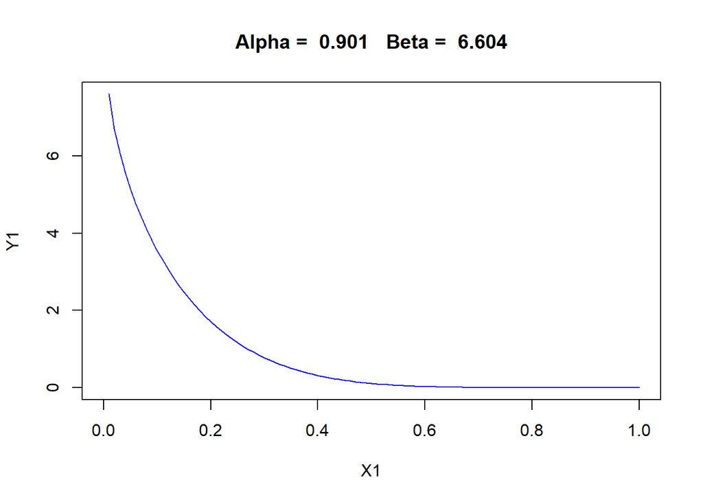

```r
# 𝜃~ 0 < .12 < .2
# Mean = alpha/(alpha + beta) => .12 = x1/(x1+x2)
# Maximum = (alpha - 1) / (alpha + beta -2) => .2 = x1-1/(x1 + x2 -2)
# Put in matrix format and solve for system of equations

A <- cbind(c(7.33, 4),c(-1, -1))

b <- cbind(c(0, -3))

alpha_Beta1 <- solve(A,b)

X1 <- seq(0, 1, by=0.01)

Y1 <- dbeta(X1, alpha_Beta1[1], alpha_Beta1[2])

plot(X1, Y1, type= 'l', col = 'blue',
     main = paste("Alpha = ", round(alpha_Beta1[1],3), " ", "Beta = ", round(alpha_Beta1[2],3) ))
```

2. (5 pts) Another researcher with more experience thinks the value is likely to be 0.11 and is 95% sure that it is between 0.05 and 0.16. Find the values of 𝛼 and 𝛽 that meets this requirement. (note that different people may have different values that meet these criteria.

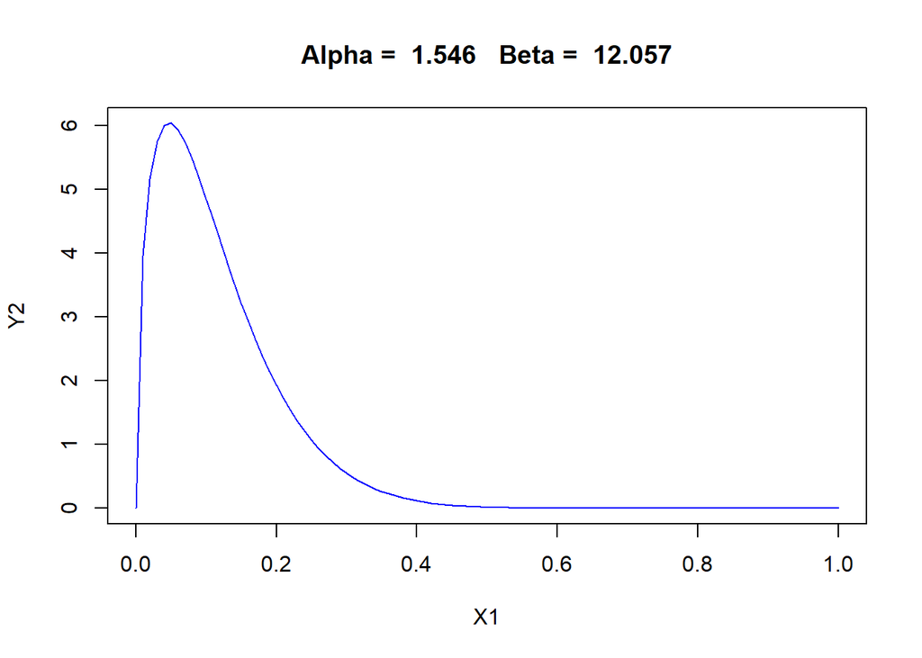

```r
# 𝜃~ 0.05 < .11 < .16
# Mean = alpha/(alpha + beta) => .11 = x1/(x1+x2)
# Maximum = (alpha - 1) / (alpha + beta -2) => .16 = x1-1/(x1 + x2 -2)
# Put in matrix format and solve for system of equations

A <- cbind(c(8.09, 5.25),c(-1, -1))

b <- cbind(c(0, -4.25))

alpha_Beta2 <- solve(A,b)

X1 <- seq(0, 1, by=0.01)

# Shifting distribution by .05
new_alpha <- alpha_Beta2[1] + .05
new_beta <- alpha_Beta2[2] - .05

Y2 <- dbeta(X1, new_alpha, new_beta)

plot(X1, Y2, type= 'l', col = 'blue',
     main = paste("Alpha = ", round(new_alpha,3), " ", "Beta = ", round(new_beta,3) ))
```

3. (5 pts) A study is performed and of 96 subjects 12 agree with the statement. Write down the likelihood for the experiment.

Likelihood = Beta(𝛼+ # of Successes, 𝛽 + # of samples(n) - # of Successes)

4. (5 pts) Find the posterior distributions for 𝜃 for items a. and b. above. Note you should have two answers.

```r
n = 96
bernoulli_success = 12

posterior_alpha1 <- alpha_Beta1[1] + bernoulli_success
posterior_beta1 <- alpha_Beta1[2] + n - bernoulli_success

posterior_alpha2 <- new_alpha + bernoulli_success
posterior_beta2 <- new_beta + n - bernoulli_success



posterior_distribution1 = beta(posterior_alpha1, posterior_beta1)

posterior_distribution2 = beta(posterior_alpha2, posterior_beta2)


posterior_distribution1; posterior_distribution2
```

```
## [1] 9.345748e-18
```

```
## [1] 1.150215e-18
```

5. (5 pts) Find the posterior means and standard deviations for 𝜃 for items a. and b. above. Note you should have two answers.

```r
posterior_means1 <- posterior_alpha1 / posterior_alpha1 + posterior_beta1

posterior_means2 <- posterior_alpha2 / posterior_alpha2 + posterior_beta2


posterior_means1; posterior_means2
```

```
## [1] 91.6036
```

```
## [1] 97.05651
```

```r
sd1 <- sqrt(posterior_alpha1 * posterior_beta1 / posterior_alpha1 + posterior_beta1^2 * (posterior_alpha1 + posterior_beta1 + 1))

sd2 <- sqrt(posterior_alpha2 * posterior_beta2 / posterior_alpha2 + posterior_beta2^2 * (posterior_alpha2 + posterior_beta2 + 1))


sd1; sd2
```

```
## [1] 926.2664
```

```
## [1] 1010.254
```

```r
cred_interval1 <- qbeta(c(0.05,.95),  posterior_alpha1, posterior_beta1)

cred_interval2 <- qbeta(c(0.05,.95),  posterior_alpha2, posterior_beta2)

cred_interval1; cred_interval2
```

```
## [1] 0.07590527 0.18164251
```

```
## [1] 0.07629273 0.17872552
```

7. (5 pts) Create plots with the prior and posterior distributions for 𝜃 for each of the items a. and b. above.

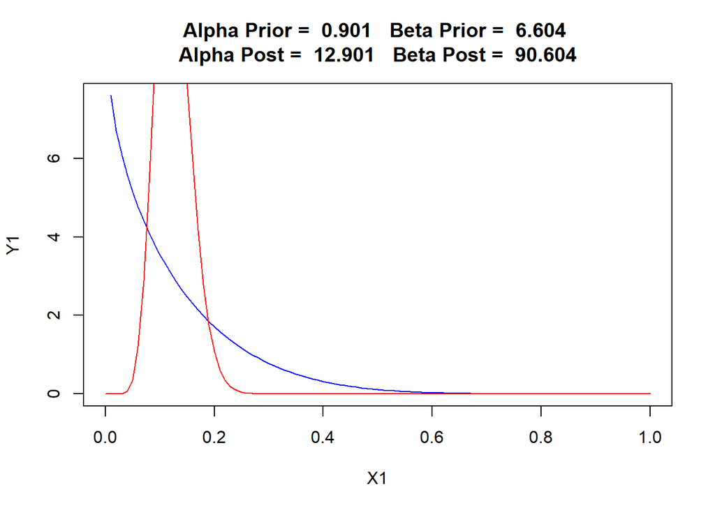

```r
post1 <- dbeta(X1, posterior_alpha1, posterior_beta1)

prior1 <- plot(X1, Y1, type= 'l', col = 'blue',
     main = paste("Alpha Prior = ", round(alpha_Beta1[1],3), " ", "Beta Prior = ", round(alpha_Beta1[2],3),
     sub = paste("\nAlpha Post = ", round(posterior_alpha1,3), " ", "Beta Post = ", round(posterior_beta1,3) )))
lines(X1, post1, col = 'red')
```

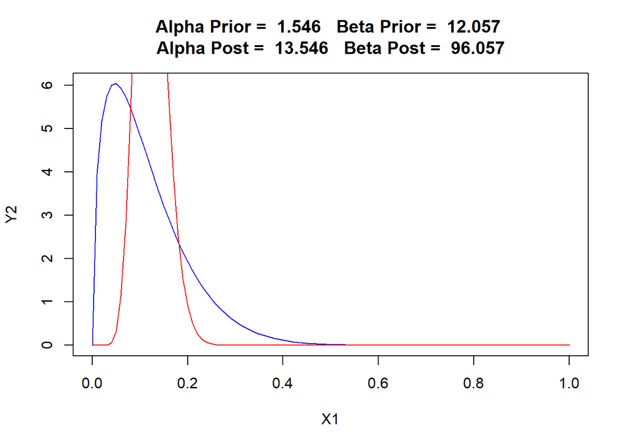

```r
post2 <- dbeta(X1, posterior_alpha2, posterior_beta2)
prior2 <- plot(X1, Y2, type= 'l', col = 'blue',
     main = paste("Alpha Prior = ", round(new_alpha,3), " ", "Beta Prior = ", round(new_beta,3) ,
     sub = paste("\nAlpha Post = ", round(posterior_alpha2,3), " ", "Beta Post = ", round(posterior_beta2,3) )))
lines(X1, post2, col = 'red')
```